# Discussion 6

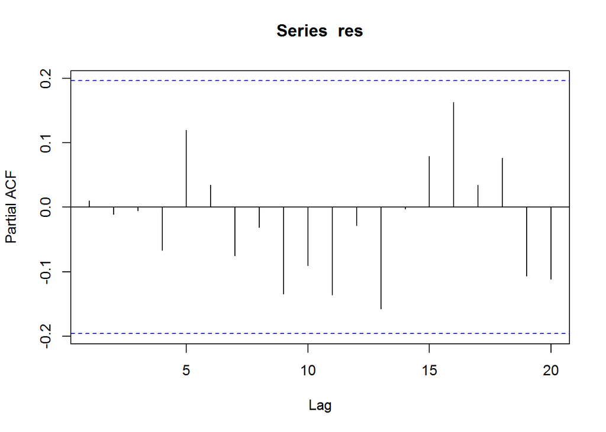

```r
pacf(res)
```

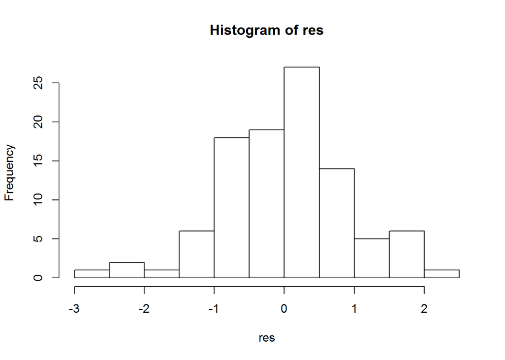

```r
hist(res)
```

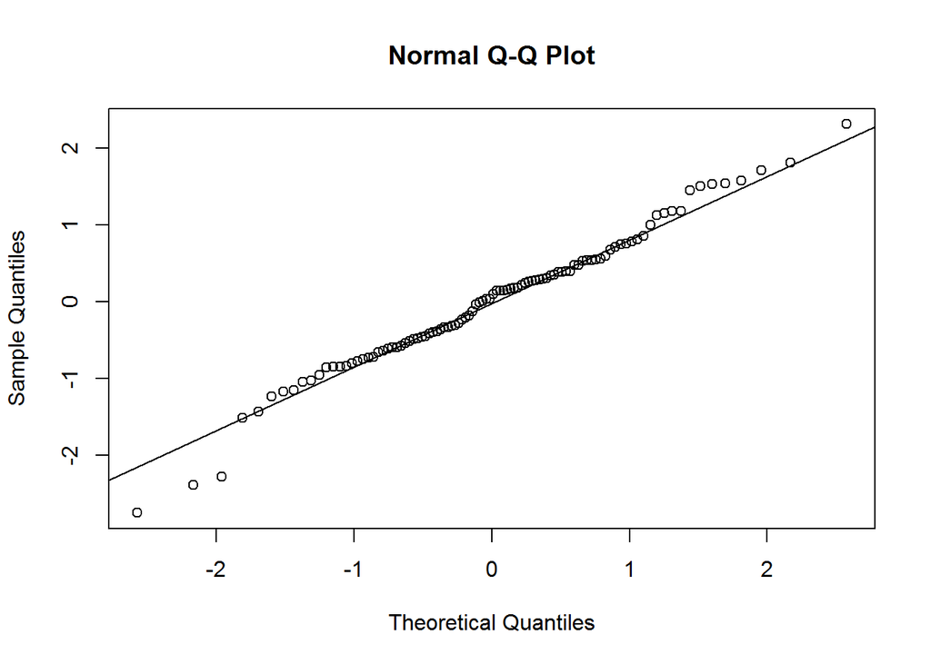

```r
qqnorm(res); qqline(res)
```

The residuals resemble white noise, so the model seems to be a good fit. If the residuals didn’t look like white noise, then we’d have to consider different models until we find one for which the residuals are close to WN.

### Forecasts

Now that we found a model that fits the data reasonably well, let’s use it to make forecasts 5 time points into the future. This can easily be done with the `predict()` function.

```r
h = 5
predict(mod, n.ahead=h)
```

```
## $pred
## Time Series:
## Start = 101
## End = 105
## Frequency = 1
## [1]  0.84042151  0.28628945 -0.01795916 -0.01795916 -0.01795916
##
## $se
## Time Series:
## Start = 101
## End = 105
## Frequency = 1
## [1] 0.8842544 0.9937206 1.0089570 1.0089570 1.0089570
```

Note that the output consists of two vectors. These are the forecast values and their standard errors, respectively. We can extract the elements individually.

```r
fcast = predict(mod,n.ahead=h)
f.vals = fcast$pred
f.se = fcast$se
```

### Plotting Forecasts

Finally, it is useful to plot the forecast values to see how they compare to the rest of the sample. This can be done with the `points()` commands. Make sure to keep track of the time values (X-axis).

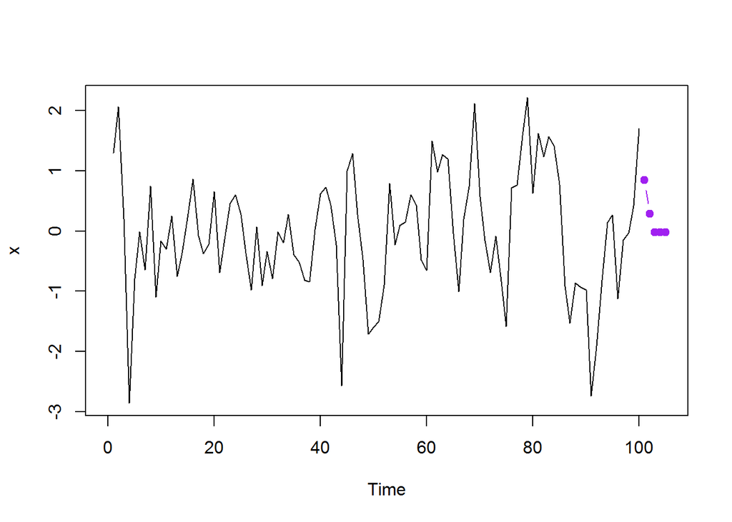

```r
plot.ts(x,xlim=c(0,n+h))
points(x=n+1:h, y=f.vals, col='purple',type='b',pch=19)
```

Let’s add forecast margins of one and two standard errors. I’ll use the function `polygon()` here as a quick way of doing that.

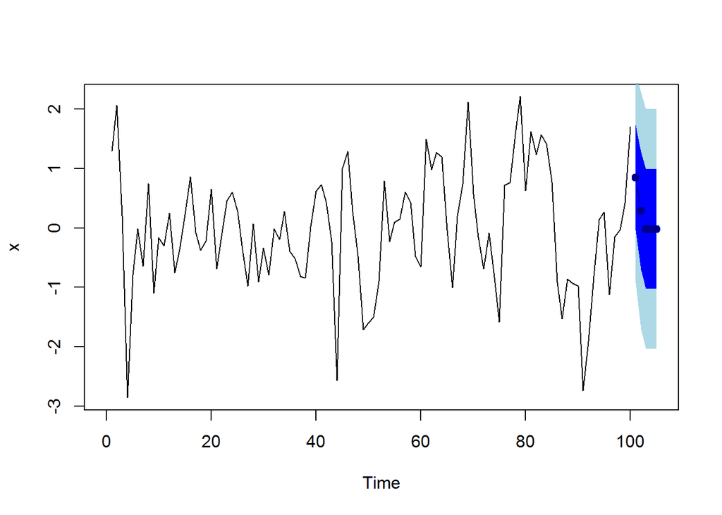

```r
upper1 = f.vals + f.se
lower1 = f.vals - f.se
upper2 = f.vals + 2 * f.se
lower2 = f.vals - 2 * f.se

plot.ts(x,xlim=c(0,n+h))
polygon(x=c(n+(1:h),n+(h:1)), y=c(upper2,lower2[h:1]), col='lightblue', border=NA)
polygon(x=c(n+(1:h),n+(h:1)), y=c(upper1,lower1[h:1]), col='blue', border=NA)
points(x=n+1:h, y=f.vals, col='darkblue',type='b',pch=19)
```

### Connection with Causality

Recall that a big practical benefit of the causal representation is its usefulness in computing forecast errors. Let’s take a closer look.

First, take a look at all the stuff that an ARIMA object contains.

```r
mod
```

```
##
## Call:
## arima(x = x, order = c(0, 0, 2))
##
## Coefficients:
##          ma1     ma2  intercept
##       0.5128  0.1975    -0.0180
## s.e.  0.0953  0.1126     0.1505
##
## sigma^2 estimated as 0.7819:  log likelihood = -129.73,  aic = 267.47
```

```r
names(mod)
```

```
##  [1] "coef"      "sigma2"    "var.coef"  "mask"      "loglik"
##  [6] "aic"       "arma"      "residuals" "call"      "series"
## [11] "code"      "n.cond"    "nobs"      "model"
```

In particular, we can access the estimated coefficients and noise variance as follows.

```r
mod$coef
```

```
##         ma1         ma2   intercept
##  0.51275241  0.19754647 -0.01795916
```

```r
sigma.hat = sqrt(mod$sigma2)
```

Estimates of the coefficents of the causal representations ($\hat{\psi}_j, j = 1, 2, 3, \cdots$ in lecture notation) can be computed from the estimated model coefficients using `ARMAtoMA`. Usually the first 20 or so are enough for practical purposes.

```r
psi = ARMAtoMA(ar=NULL, ma=mod$coef[1:2], lag.max=20)
psi
```

```
##  [1] 0.5127524 0.1975465 0.0000000 0.0000000 0.0000000 0.0000000 0.0000000
##  [8] 0.0000000 0.0000000 0.0000000 0.0000000 0.0000000 0.0000000 0.0000000
## [15] 0.0000000 0.0000000 0.0000000 0.0000000 0.0000000 0.0000000
```

Note that in this case, since the model is a moving average, it is its own causal representation and the estimated $\phi_j$ are equal to the estimated $\theta_j$. However, the above code can be used to get $\phi_j$ estimates of any causal ARMA model. One just needs to supply the vectors of AR and MA coefficients, and the maximum value of $j$ for the $\hat{\phi}_j$.

We can now apply the formulas from Lecture Notes 13-14 to compute the estimated forecast standard error. $\hat{\sigma}(h)$ from the $\hat{\phi}_j$.

First off, $\hat{\sigma}^2(1) = \hat{\sigma}^2$. For any $k>1$, we can compute $\hat{\sigma}^2(k)$ using the following code, and appropriate values of $k$.

```r
k = 2
(1 + sum(psi[1:(k-1)]^2))*sigma.hat^2
```

```
## [1] 0.9874806
```

To expedite the process, we can use `sapply()` to apply the above function to all lags $k = 2, 3, \cdots h$, where $h$ is our forecast horizon. Don’t forget to take the square root if you’re looking for standard error, not variance.

```r
h=5
my.se = c(1,sapply(X=2:h, FUN = function(k){(1+sum(psi[1:(k-1)]^2))})) * sigma.hat^2
my.se = sqrt(my.se)
```

Let’s check how these estimated forecast standard errors compare to the ones computed by `predict()`.

```r
my.se
```

```
## [1] 0.8842544 0.9937206 1.0089570 1.0089570 1.0089570
```

```r
f.se
```

```
## Time Series:
## Start = 101
## End = 105
## Frequency = 1
## [1] 0.8842544 0.9937206 1.0089570 1.0089570 1.0089570
```

### Exercise

Use the sample vector `x` above. First, save the last 5 observations as a separate vector. Repeat the above process, and fit a model using only the first 95 observations. Then use the model to forecast the last 5 observations. Plot the actual observations you saved earlier and the forecasts on the same plot.